# Zadania 10

Szymon Szrajer

10 06 2021

## ZADANIE 1

**Hipoteza robocza:** Średnie BMR różni się pomiędzy płciami. Średnie BMR zależy od masy ciała. Wystepują różnice między zależnością BMR od masy ciała ze względu na płeć.

**Hipoteza zerowa:** Średnie BMR nie różni się pomiędzy płciami. Średnie BMR nie zależy od masy ciała. Nie wystepują różnice między zależnością BMR od masy ciała ze względu na płeć.

**Hipoteza alternatywna:** Średnie BMR różni się pomiędzy płciami. Średnie BMR zależy od masy ciała. Wystepują różnice między zależnością BMR od masy ciała ze względu na płeć.

**Model ANOVA:** ANOVA- osobne nachylenia: BMR=Y0+S+MB+(S∗MB)+e ANOVA- wspólne nachylenia BMR=Y0+S+MB+e

**Założenia:** Niezalezność obserwacji, homogeniczność wariancji, liniowość zależności, normalnośc rozkladu.

```r
voles <- read.delim(file = "Voles_BMR_MB_S.txt", header = T)
```

```r
voles %>% group_by(S)  %>%
  summarize(mean = mean(BMR), median = median(BMR),
            maximum = max(BMR), minimum = min(BMR), sd = sd(BMR),
            N = length(BMR))
```

```
## # A tibble: 2 x 7
##   S      mean median maximum minimum    sd     N
##   <chr> <dbl>  <dbl>   <dbl>   <dbl> <dbl> <int>
## 1 F      46.3   46      64      33.9  7.34    45
## 2 M      48.9   47.8    64.5    40.3  5.18    45
```

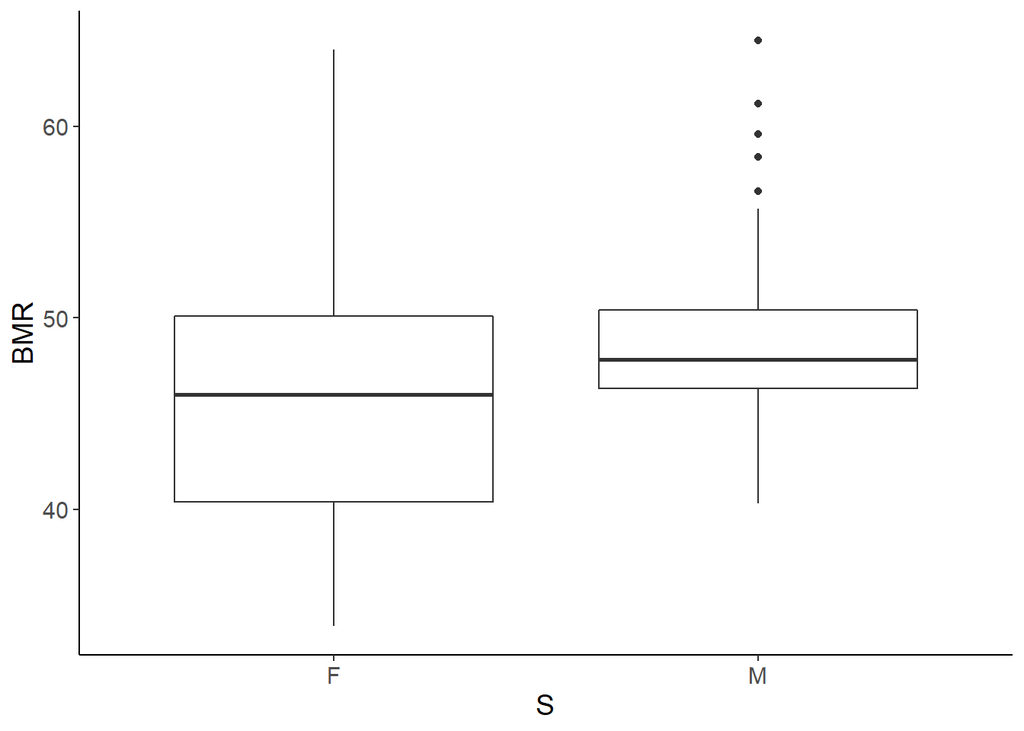

```r
ggplot(data = voles, mapping = aes(x = S, y = BMR)) + geom_boxplot() + theme_classic() +
  theme(text = element_text(size = 14))
```

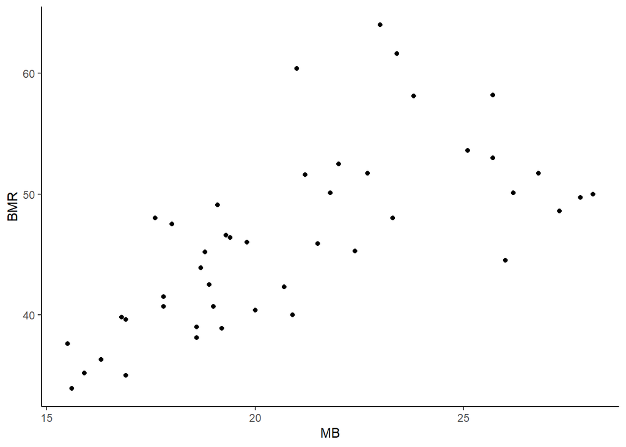

```r
ggplot(data=subset(voles, S=="F"), aes(x = MB, y = BMR)) + geom_point() + theme_classic()
```

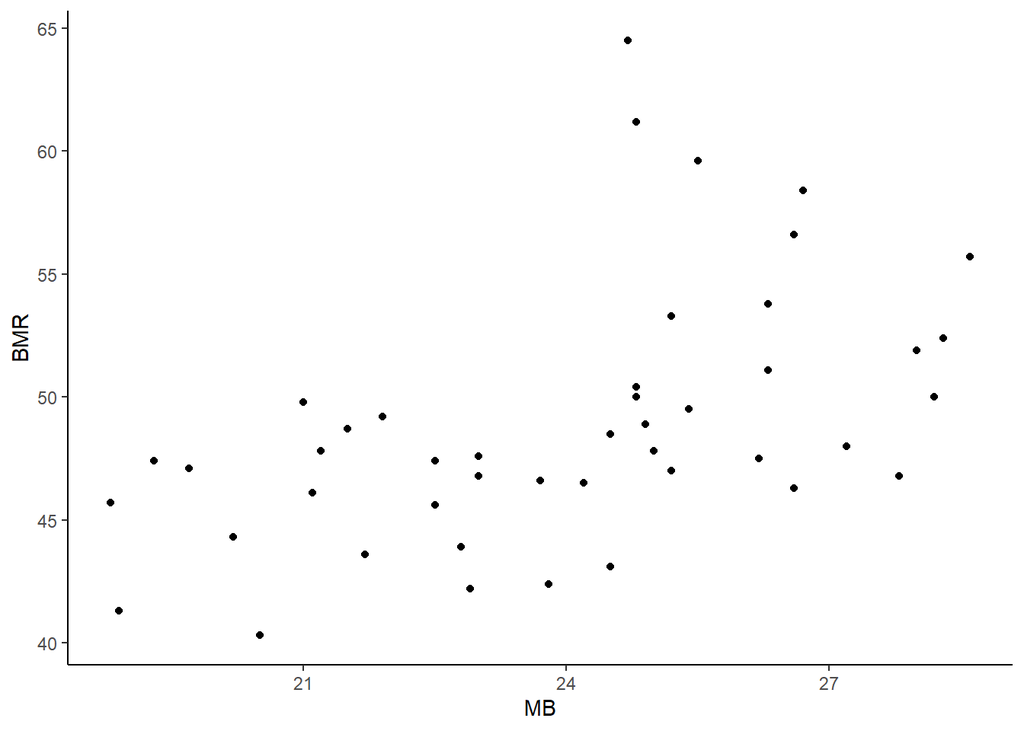

```r
ggplot(data=subset(voles, S=="M"), aes(x = MB, y = BMR)) + geom_point() + theme_classic()
```

ANOVA do porównania średnich wartości MB w zależności od płci:

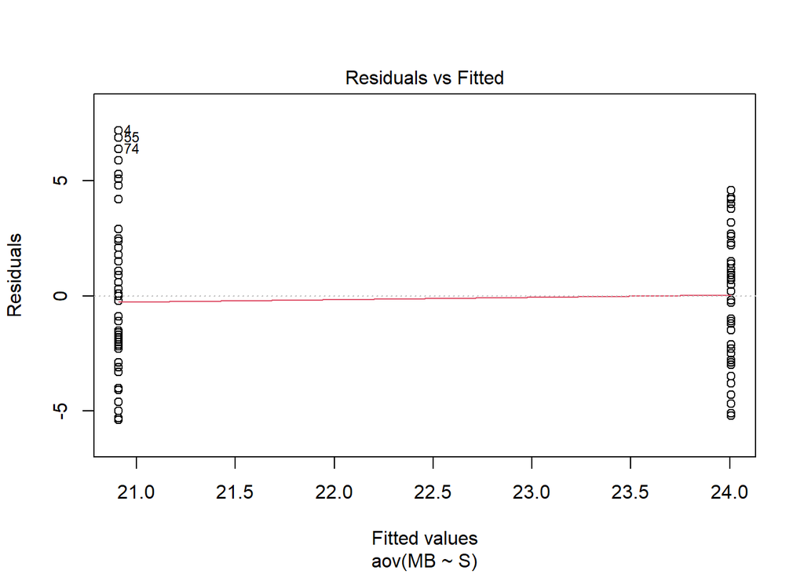

```r
simpleANOVA_MB <- aov(MB ~ S, data = voles)
plot(simpleANOVA_MB, 1)
```

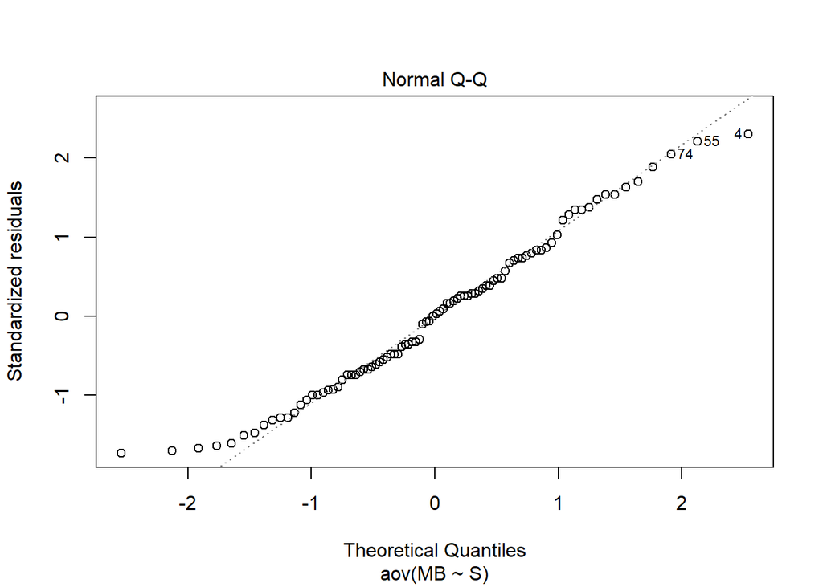

```r
plot(simpleANOVA_MB, 2)
```

```r
summary(simpleANOVA_MB)
```

```
##             Df Sum Sq Mean Sq F value  Pr(>F)
## S            1  215.9  215.92   21.74 1.1e-05 ***
## Residuals   88  873.9    9.93
## ---
## Signif. codes:  0 '***' 0.001 '**' 0.01 '*' 0.05 '.' 0.1 ' ' 1
```

ANOVA do porównania średnich wartości BMR w zależności od płci:

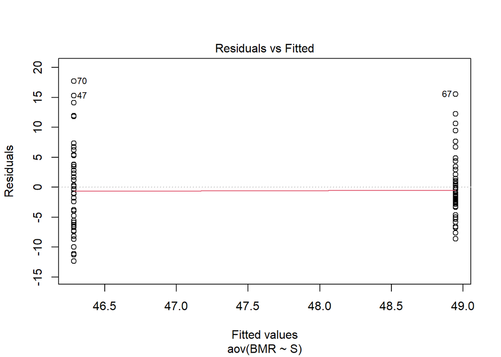

```r
simpleANOVA_BMR <- aov(BMR ~ S, data = voles)
plot(simpleANOVA_BMR, 1)
```

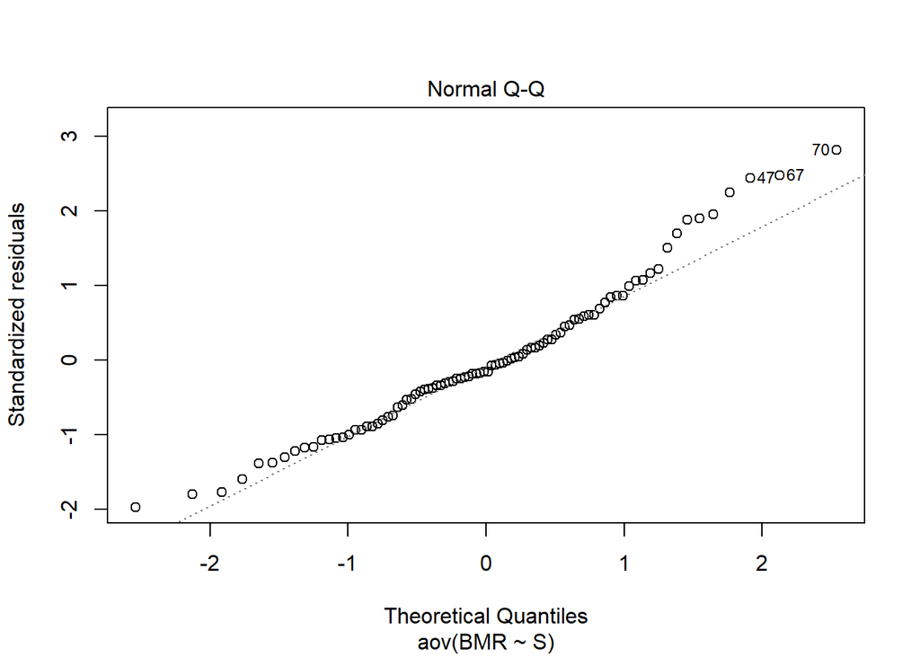

```r
plot(simpleANOVA_BMR, 2)
```

```r
summary(simpleANOVA_BMR)
```

```
##             Df Sum Sq Mean Sq F value Pr(>F)
## S            1    159  159.47   3.952 0.0499 *
## Residuals   88   3551   40.35
## ---
## Signif. codes:  0 '***' 0.001 '**' 0.01 '*' 0.05 '.' 0.1 ' ' 1
```

Prosty model regresji linowej, opisujący zależność MB od masy ciała (bez uwzględniania efektu płci)

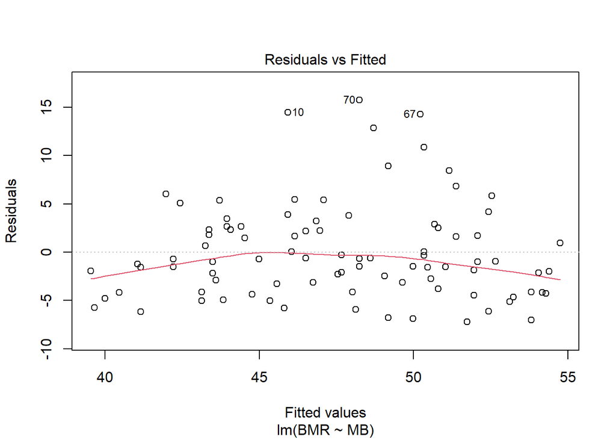

```r
simpleLm <- lm(BMR ~ MB, data = voles)
plot(simpleLm,1)
```

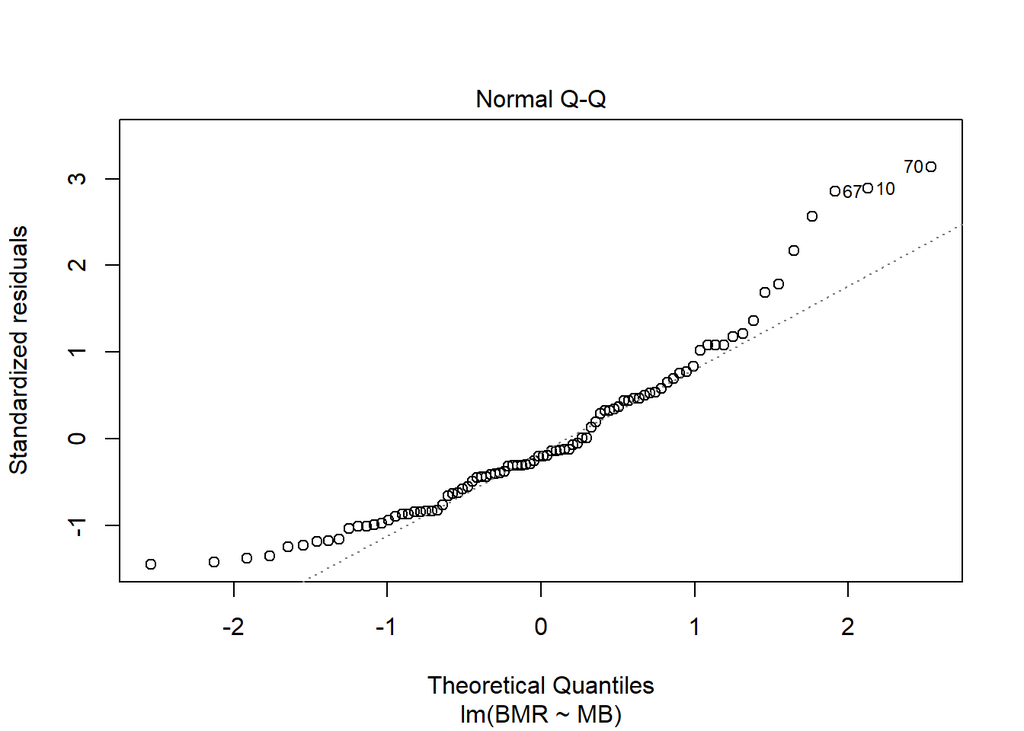

```r
plot(simpleLm,2)
```

```r
summary(simpleLm)
```

```
##
## Call:
## lm(formula = BMR ~ MB, data = voles)
##
## Residuals:
##     Min      1Q  Median      3Q     Max
## -7.2289 -4.0347 -0.9807  2.4589 15.7548
##
## Coefficients:
##             Estimate Std. Error t value Pr(>|t|)
## (Intercept)  21.5368     3.4736   6.200 1.78e-08 ***
## MB            1.1612     0.1528   7.597 3.06e-11 ***
## ---
## Signif. codes:  0 '***' 0.001 '**' 0.01 '*' 0.05 '.' 0.1 ' ' 1
##
## Residual standard error: 5.046 on 88 degrees of freedom
## Multiple R-squared:  0.3961, Adjusted R-squared:  0.3892
## F-statistic: 57.72 on 1 and 88 DF,  p-value: 3.056e-11
```

```r
anova(simpleLm)
```

```
## Analysis of Variance Table
##
## Response: BMR
##           Df Sum Sq Mean Sq F value    Pr(>F)
## MB         1 1469.5 1469.53  57.718 3.056e-11 ***
## Residuals 88 2240.5   25.46
## ---
## Signif. codes:  0 '***' 0.001 '**' 0.01 '*' 0.05 '.' 0.1 ' ' 1
```

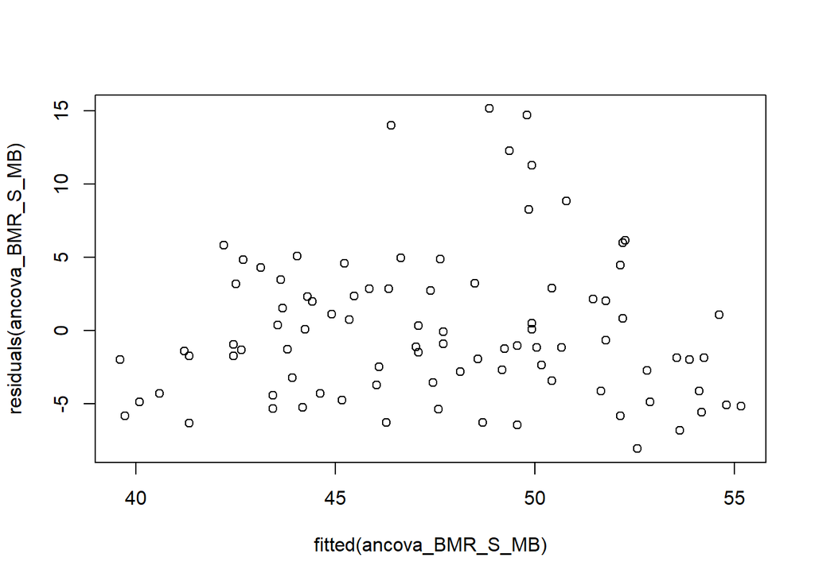

```r
ancova_BMR_S_MB <- lm(BMR ~ S + MB, data = voles)
plot(fitted(ancova_BMR_S_MB), residuals(ancova_BMR_S_MB))
```

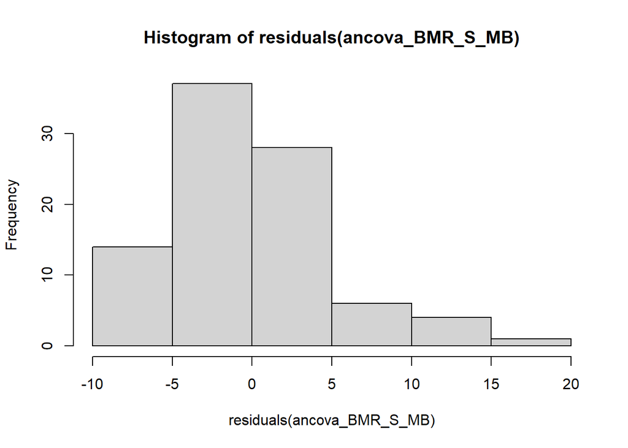

```r
hist(residuals(ancova_BMR_S_MB))
```

```r
summary(ancova_BMR_S_MB)
```

```
##
## Call:
## lm(formula = BMR ~ S + MB, data = voles)
##
## Residuals:
##    Min     1Q Median     3Q    Max
## -8.076 -3.684 -1.133  2.817 15.131
##
## Coefficients:
##             Estimate Std. Error t value Pr(>|t|)
## (Intercept)  20.4450     3.6481   5.604 2.42e-07 ***
## SM           -1.1660     1.1882  -0.981    0.329
## MB            1.2358     0.1707   7.239 1.70e-10 ***
## ---
## Signif. codes:  0 '***' 0.001 '**' 0.01 '*' 0.05 '.' 0.1 ' ' 1
##
## Residual standard error: 5.047 on 87 degrees of freedom
## Multiple R-squared:  0.4027, Adjusted R-squared:  0.389
## F-statistic: 29.33 on 2 and 87 DF,  p-value: 1.837e-10
```

```r
anova(ancova_BMR_S_MB)
```

```
## Analysis of Variance Table
##
## Response: BMR
##           Df  Sum Sq Mean Sq F value    Pr(>F)
## S          1  159.47  159.47  6.2607   0.01421 *
## MB         1 1334.59 1334.59 52.3966 1.697e-10 ***
## Residuals 87 2215.98   25.47
## ---
## Signif. codes:  0 '***' 0.001 '**' 0.01 '*' 0.05 '.' 0.1 ' ' 1
```

```r
Anova(ancova_BMR_S_MB, type="III")
```

```
## Anova Table (Type III tests)
##
## Response: BMR
##              Sum Sq Df F value    Pr(>F)
## (Intercept)  799.98  1 31.4076 2.419e-07 ***
## S             24.53  1  0.9631    0.3291
## MB          1334.59  1 52.3966 1.697e-10 ***
## Residuals   2215.98 87
## ---
## Signif. codes:  0 '***' 0.001 '**' 0.01 '*' 0.05 '.' 0.1 ' ' 1
```

MB -> S

```r
ancova_BMR_S_MB1 <- lm(BMR ~ MB + S, data = voles)
anova(ancova_BMR_S_MB1)
```

```
## Analysis of Variance Table
##
## Response: BMR
##           Df  Sum Sq Mean Sq F value    Pr(>F)
## MB         1 1469.53 1469.53 57.6942 3.258e-11 ***
## S          1   24.53   24.53  0.9631    0.3291
## Residuals 87 2215.98   25.47
## ---
## Signif. codes:  0 '***' 0.001 '**' 0.01 '*' 0.05 '.' 0.1 ' ' 1
```

```r
options(contrasts = c("contr.sum", "contr.poly"))
```

S -> MB

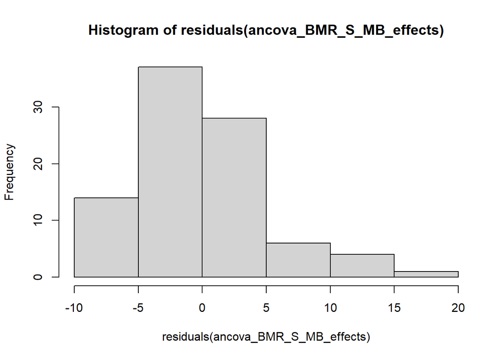

```r
ancova_BMR_S_MB_effects <- lm(BMR ~ S + MB, data = voles)
hist(residuals(ancova_BMR_S_MB_effects))
```

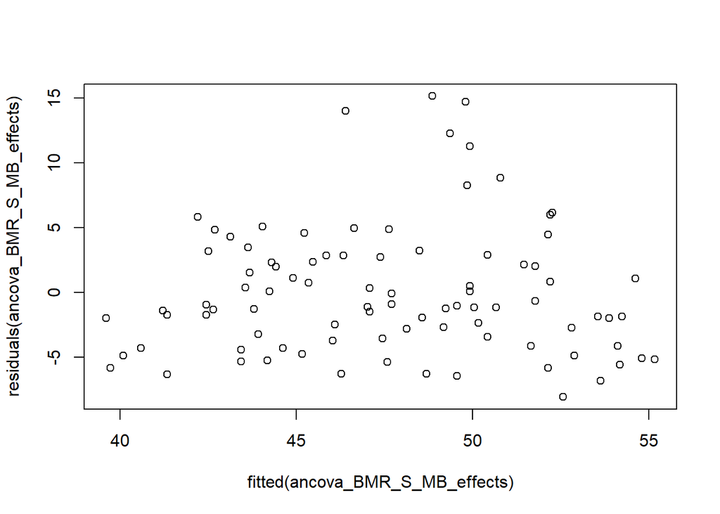

```r
plot(fitted(ancova_BMR_S_MB_effects), residuals(ancova_BMR_S_MB_effects))
```

```r
summary(ancova_BMR_S_MB_effects)
```

```
##
## Call:
## lm(formula = BMR ~ S + MB, data = voles)
##
## Residuals:
##    Min     1Q Median     3Q    Max
## -8.076 -3.684 -1.133  2.817 15.131
##
## Coefficients:
##             Estimate Std. Error t value Pr(>|t|)
## (Intercept)  19.8620     3.8709   5.131 1.73e-06 ***
## S1            0.5830     0.5941   0.981    0.329
## MB            1.2358     0.1707   7.239 1.70e-10 ***
## ---
## Signif. codes:  0 '***' 0.001 '**' 0.01 '*' 0.05 '.' 0.1 ' ' 1
##
## Residual standard error: 5.047 on 87 degrees of freedom
## Multiple R-squared:  0.4027, Adjusted R-squared:  0.389
## F-statistic: 29.33 on 2 and 87 DF,  p-value: 1.837e-10
```

```r
anova(ancova_BMR_S_MB_effects)
```

```
## Analysis of Variance Table
##
## Response: BMR
##           Df  Sum Sq Mean Sq F value    Pr(>F)
## S          1  159.47  159.47  6.2607   0.01421 *
## MB         1 1334.59 1334.59 52.3966 1.697e-10 ***
## Residuals 87 2215.98   25.47
## ---
## Signif. codes:  0 '***' 0.001 '**' 0.01 '*' 0.05 '.' 0.1 ' ' 1
```

```r
Anova(ancova_BMR_S_MB_effects, type="III")
```

```
## Anova Table (Type III tests)
##
## Response: BMR
##              Sum Sq Df F value    Pr(>F)
## (Intercept)  670.62  1 26.3286 1.731e-06 ***
## S             24.53  1  0.9631    0.3291
## MB          1334.59  1 52.3966 1.697e-10 ***
## Residuals   2215.98 87
## ---
## Signif. codes:  0 '***' 0.001 '**' 0.01 '*' 0.05 '.' 0.1 ' ' 1
```

MB -> S

```r
ancova_BMR_S_MB_effects1 <- lm(BMR ~ MB + S, data = voles)
anova(ancova_BMR_S_MB_effects1)
```

```
## Analysis of Variance Table
##
## Response: BMR
##           Df  Sum Sq Mean Sq F value    Pr(>F)
## MB         1 1469.53 1469.53 57.6942 3.258e-11 ***
## S          1   24.53   24.53  0.9631    0.3291
## Residuals 87 2215.98   25.47
## ---
## Signif. codes:  0 '***' 0.001 '**' 0.01 '*' 0.05 '.' 0.1 ' ' 1
```